# DATA 624 Project 2

Ron Balaban, Brandon Chung, Yanyi Li, Chi Hang(Philip) Cheung, Jiaxin Zheng

2025-03-13

```r
library(caret)
library(dplyr)
library(e1071)
library(forecast)
library(feasts)
library(ggplot2)
library(ggfortify)
library(GGally)
library(knitr)
library(kernlab)
library(lubridate)
library(latex2exp)
library(missForest)
library(mice)
library(readxl)
library(readr)
library(tsibble)
library(tidyr)
library(VIM)
library(writexl)
library(tibble)
library(corrplot)
```

## —————————————————————————-

#### Instructions

This is role playing. I am your new boss. I am in charge of production at ABC Beverage, and you are a team of data scientists reporting to me. My leadership has told me that new regulations require us to understand our manufacturing process, the predictive factors, and be able to report to them our predictive model of PH.

Please use the historical data set I am providing. Build and report the factors in BOTH a technical and non-technical report. I like to use Word and Excel. Please provide your non-technical report in a business-friendly, readable document and your predictions in an Excel-readable format. The technical report should show clearly the models you tested and how you selected your final approach.

Please submit both Rpubs links and .rmd files or other readable formats for technical and non-technical reports. Also submit the Excel file showing the prediction of your models for pH.

———–Starts Here———–

### To load the training and test datasets. I have uploaded the two files and converted them to CSV files in my repo, and made the links available to load:

# Loading data:

```r
train_og<- read.csv('https://raw.githubusercontent.com/stormwhale/data-mines/refs/heads/main/StudentData.csv')
new_test_data<- read.csv('https://raw.githubusercontent.com/stormwhale/data-mines/refs/heads/main/StudentEvaluation.csv')
```

# Data Exploration

```r
# Summary statistics
summary(train_og)
```

```
##   Brand.Code         Carb.Volume     Fill.Ounces      PC.Volume
##  Length:2571        Min.   :5.040   Min.   :23.63   Min.   :0.07933
##  Class :character   1st Qu.:5.293   1st Qu.:23.92   1st Qu.:0.23917
##  Mode  :character   Median :5.347   Median :23.97   Median :0.27133
##                     Mean   :5.370   Mean   :23.97   Mean   :0.27712
##                     3rd Qu.:5.453   3rd Qu.:24.03   3rd Qu.:0.31200
##                     Max.   :5.700   Max.   :24.32   Max.   :0.47800
##                     NA's   :10      NA's   :38      NA's   :39
##  Carb.Pressure     Carb.Temp          PSC             PSC.Fill
##  Min.   :57.00   Min.   :128.6   Min.   :0.00200   Min.   :0.0000
##  1st Qu.:65.60   1st Qu.:138.4   1st Qu.:0.04800   1st Qu.:0.1000
##  Median :68.20   Median :140.8   Median :0.07600   Median :0.1800
##  Mean   :68.19   Mean   :141.1   Mean   :0.08457   Mean   :0.1954
##  3rd Qu.:70.60   3rd Qu.:143.8   3rd Qu.:0.11200   3rd Qu.:0.2600
##  Max.   :79.40   Max.   :154.0   Max.   :0.27000   Max.   :0.6200
##  NA's   :27      NA's   :26      NA's   :33        NA's   :23
##     PSC.CO2           Mnf.Flow       Carb.Pressure1  Fill.Pressure
##  Min.   :0.00000   Min.   :-100.20   Min.   :105.6   Min.   :34.60
##  1st Qu.:0.02000   1st Qu.:-100.00   1st Qu.:119.0   1st Qu.:46.00
##  Median :0.04000   Median :  65.20   Median :123.2   Median :46.40
##  Mean   :0.05641   Mean   :  24.57   Mean   :122.6   Mean   :47.92
##  3rd Qu.:0.08000   3rd Qu.: 140.80   3rd Qu.:125.4   3rd Qu.:50.00
##  Max.   :0.24000   Max.   : 229.40   Max.   :140.2   Max.   :60.40
##  NA's   :39        NA's   :2         NA's   :32      NA's   :22
##  Hyd.Pressure1   Hyd.Pressure2   Hyd.Pressure3   Hyd.Pressure4
##  Min.   :-0.80   Min.   : 0.00   Min.   :-1.20   Min.   : 52.00
##  1st Qu.: 0.00   1st Qu.: 0.00   1st Qu.: 0.00   1st Qu.: 86.00
##  Median :11.40   Median :28.60   Median :27.60   Median : 96.00
##  Mean   :12.44   Mean   :20.96   Mean   :20.46   Mean   : 96.29
##  3rd Qu.:20.20   3rd Qu.:34.60   3rd Qu.:33.40   3rd Qu.:102.00
##  Max.   :58.00   Max.   :59.40   Max.   :50.00   Max.   :142.00
##  NA's   :11      NA's   :15      NA's   :15      NA's   :30
##   Filler.Level    Filler.Speed   Temperature      Usage.cont      Carb.Flow
##  Min.   : 55.8   Min.   : 998   Min.   :63.60   Min.   :12.08   Min.   :  26
##  1st Qu.: 98.3   1st Qu.:3888   1st Qu.:65.20   1st Qu.:18.36   1st Qu.:1144
##  Median :118.4   Median :3982   Median :65.60   Median :21.79   Median :3028
##  Mean   :109.3   Mean   :3687   Mean   :65.97   Mean   :20.99   Mean   :2468
##  3rd Qu.:120.0   3rd Qu.:3998   3rd Qu.:66.40   3rd Qu.:23.75   3rd Qu.:3186
##  Max.   :161.2   Max.   :4030   Max.   :76.20   Max.   :25.90   Max.   :5104
##  NA's   :20      NA's   :57     NA's   :14      NA's   :5       NA's   :2
```

[output cut: 9 more lines]

```
##  Min.   :7.880   Min.   :0.00240   Min.   : 70.0   Min.   :44.00
##  1st Qu.:8.440   1st Qu.:0.02200   1st Qu.:100.0   1st Qu.:46.00
##  Median :8.540   Median :0.03340   Median :120.0   Median :46.00
##  Mean   :8.546   Mean   :0.04684   Mean   :109.3   Mean   :47.62
##  3rd Qu.:8.680   3rd Qu.:0.06000   3rd Qu.:120.0   3rd Qu.:50.00
##  Max.   :9.360   Max.   :0.40000   Max.   :140.0   Max.   :52.00
##  NA's   :4       NA's   :12        NA's   :2       NA's   :12
##  Air.Pressurer      Alch.Rel        Carb.Rel      Balling.Lvl
##  Min.   :140.8   Min.   :5.280   Min.   :4.960   Min.   :0.00
##  1st Qu.:142.2   1st Qu.:6.540   1st Qu.:5.340   1st Qu.:1.38
##  Median :142.6   Median :6.560   Median :5.400   Median :1.48
##  Mean   :142.8   Mean   :6.897   Mean   :5.437   Mean   :2.05
##  3rd Qu.:143.0   3rd Qu.:7.240   3rd Qu.:5.540   3rd Qu.:3.14
##  Max.   :148.2   Max.   :8.620   Max.   :6.060   Max.   :3.66
##                  NA's   :9       NA's   :10      NA's   :1
```

From our data summary we can note that there are null values in most variables, these will be handled in the data pre-processing portion.

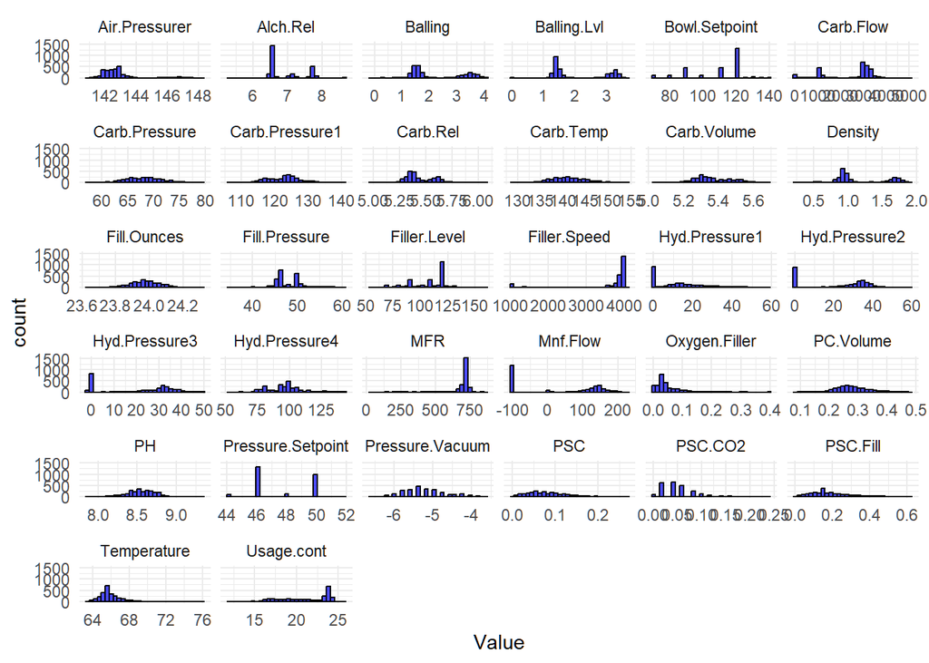

```r
# Visualizing predictor and target PH distributions

# Convert the data to long format
train_og_long <- pivot_longer(train_og, cols = where(is.numeric), names_to = "Variable", values_to = "Value")

# Create histograms for all numeric variables
ggplot(train_og_long, aes(x = Value)) +
  geom_histogram(bins = 30, fill = "blue", color = "black", alpha = 0.7) +
  facet_wrap(~Variable, scales = "free_x") +
  theme_minimal()
```

There are outliers seen in the distribution plots above, but none seem to be irregular or due to recording mistakes, so we will keep all values.

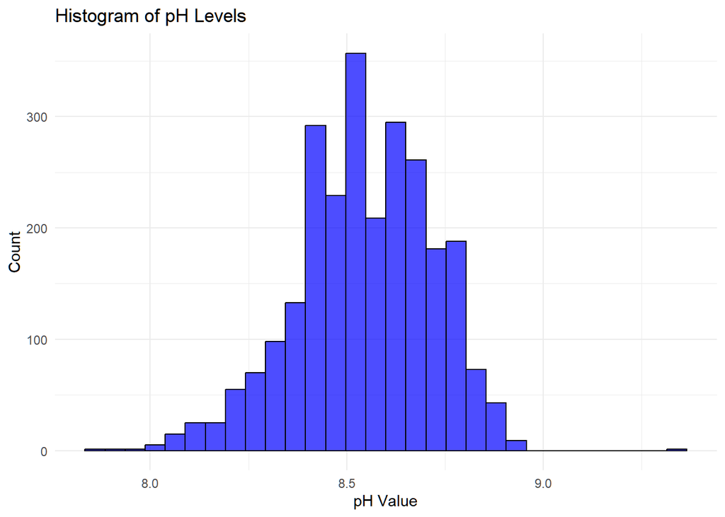

```r
# Visualizing distribution of target PH

ggplot(train_og, aes(x = PH)) +
  geom_histogram(bins = 30, fill = "blue", color = "black", alpha = 0.7) +
  labs(title = "Histogram of pH Levels", x = "pH Value", y = "Count") +
  theme_minimal()
```

There is a left sided tail in the distribution of PH, and so, how to maintain a sufficiently high pH level as a buisness question is of interest.

# Data Pre-processing

Checking for and removing predictors with near-zero variance, as such predictors have very little variability and lend no predictive power.

```r
# Viewing any predictors with near-zero variance
nzv <- nearZeroVar(train_og)
colnames(train_og)[nzv]
```

```
## [1] "Hyd.Pressure1"
```

```r
# Removing near-zero variance column "Hyd.Pressure1" from train and new_test_data dataframes
train <- train_og[, -nearZeroVar(train_og)]
new_test_data <- new_test_data[, colnames(train)]

# Viewing remaining predictor names
colnames(train)
```

```
##  [1] "Brand.Code"        "Carb.Volume"       "Fill.Ounces"
##  [4] "PC.Volume"         "Carb.Pressure"     "Carb.Temp"
##  [7] "PSC"               "PSC.Fill"          "PSC.CO2"
## [10] "Mnf.Flow"          "Carb.Pressure1"    "Fill.Pressure"
## [13] "Hyd.Pressure2"     "Hyd.Pressure3"     "Hyd.Pressure4"
## [16] "Filler.Level"      "Filler.Speed"      "Temperature"
## [19] "Usage.cont"        "Carb.Flow"         "Density"
## [22] "MFR"               "Balling"           "Pressure.Vacuum"
## [25] "PH"                "Oxygen.Filler"     "Bowl.Setpoint"
## [28] "Pressure.Setpoint" "Air.Pressurer"     "Alch.Rel"
## [31] "Carb.Rel"          "Balling.Lvl"
```

### Checking for and removing highly correlated predictors

```r
high_correlation <- findCorrelation(cor(train[,-c(1,25)]), cutoff = 0.75, exact = TRUE)
length(high_correlation)
```

```
## [1] 0
```

### To visualize missing data:

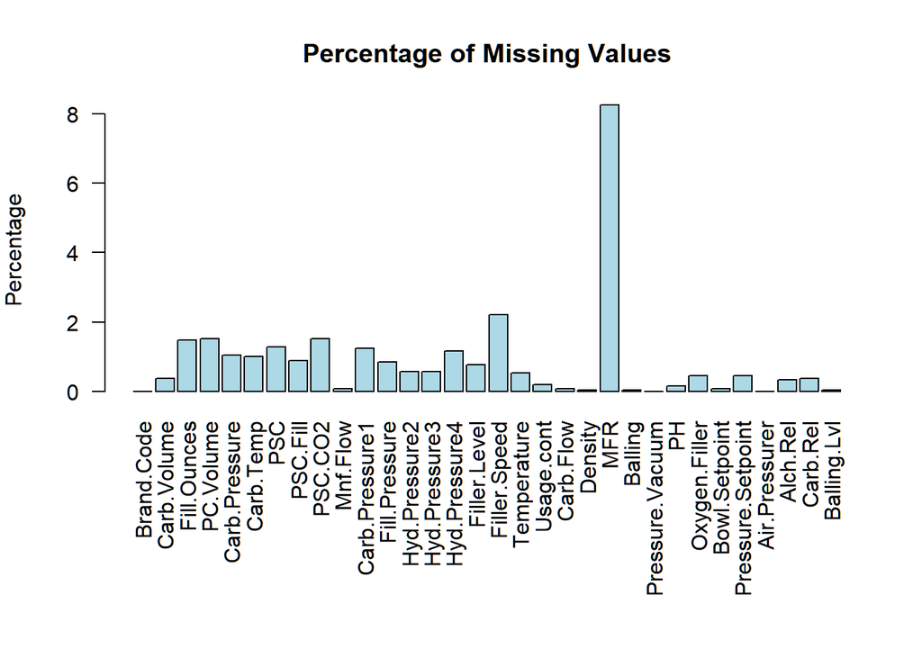

```r
#Incrase margin so the text can be read:
par(mar = c(10, 4, 4, 2))

train %>%
  sapply(function(x) sum(is.na(x)/length(x)*100)) %>%
  barplot(main = "Percentage of Missing Values",
          ylab = "Percentage",
          col = "lightblue",
          las = 2)
```

### To train split the data first:

```r
set.seed(199)
#Dropping the 4 missing pH rows from the training dataset:
train<- train %>% drop_na(PH)

#We need to replace the empty spaces with NA in the brand code column:
train$Brand.Code<- replace(train$Brand.Code, train$Brand.Code=="", NA)

#We need to convert Brand.Code column to factor for imputation:
train$Brand.Code<- as.factor(train$Brand.Code)

#Train split 80/20:
train_idx<- createDataPartition(train$PH, p = 0.8, list = FALSE)
train_data<- train[train_idx, ]
test_data<- train[-train_idx, ]

#'train/test' are now ready for imputations:
```

We tested three imputation methods and compared them to see which one will be least likely to create deviation from the overall mean of the dataset.

## Imputations

### kNN imputation:

```r
set.seed(199)
#impute train:
knn_imput_train<- kNN(train_data)
#impute test:
knn_imput_test<- kNN(test_data)
```

### randomForest imputation

```r
set.seed(199)
#Running the imputation for the training set:
rf_imput_train<- missForest(train_data)
#Running the imputation for the test set:
rf_imput_test<- missForest(test_data)

#Need to convert the imputed train object to dataframe:
rf_imput_train<- as.data.frame(rf_imput_train$ximp)
#Need to convert the imputed test object to dataframe:
rf_imput_test<- as.data.frame(rf_imput_test$ximp)
```

### MICE imputation:

```r
set.seed(199)
#Running the imputation for the training set:
mice_imput_train<- mice(train_data, m=5, maxit=50, meth='pmm', seed=100, printFlag = FALSE)
#Running the imputation for the test set:
mice_imput_test<- mice(test_data, m=5, maxit=50, meth='pmm', seed=100, printFlag = FALSE)


mice_1_train<- complete(mice_imput_train, 1) #We choose the first imputed data
mice_1_test<- complete(mice_imput_test, 1) #We choose the first imputed data
```

## To check if everything is imputed:

```r
is.na(c('knn_imput_train', 'rf_imput_train', 'mice_1_train', 'mice_1_test', 'rf_imput_test', 'knn_imput_test')) %>% any() #False
```

```
## [1] FALSE
```

To visualize the variations of the dataset after imputation through the above three methods:

## Imputed density plots

### KNN imputed density plots

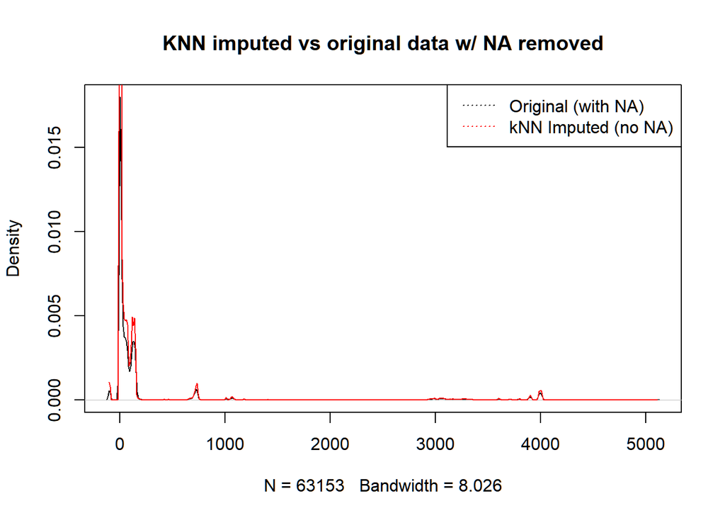

```r
plot(density(unlist(train_data[, -1]), na.rm=TRUE),
     main='KNN imputed vs original data w/ NA removed')
lines(density(unlist(knn_imput_train[, -1]), na.rm=TRUE),
      col = 'red')
legend('topright', legend = c("Original (with NA)", "kNN Imputed (no NA)"),
       col = c("black", "red"), lty = 3)
```

### RandomForest imputed density plots

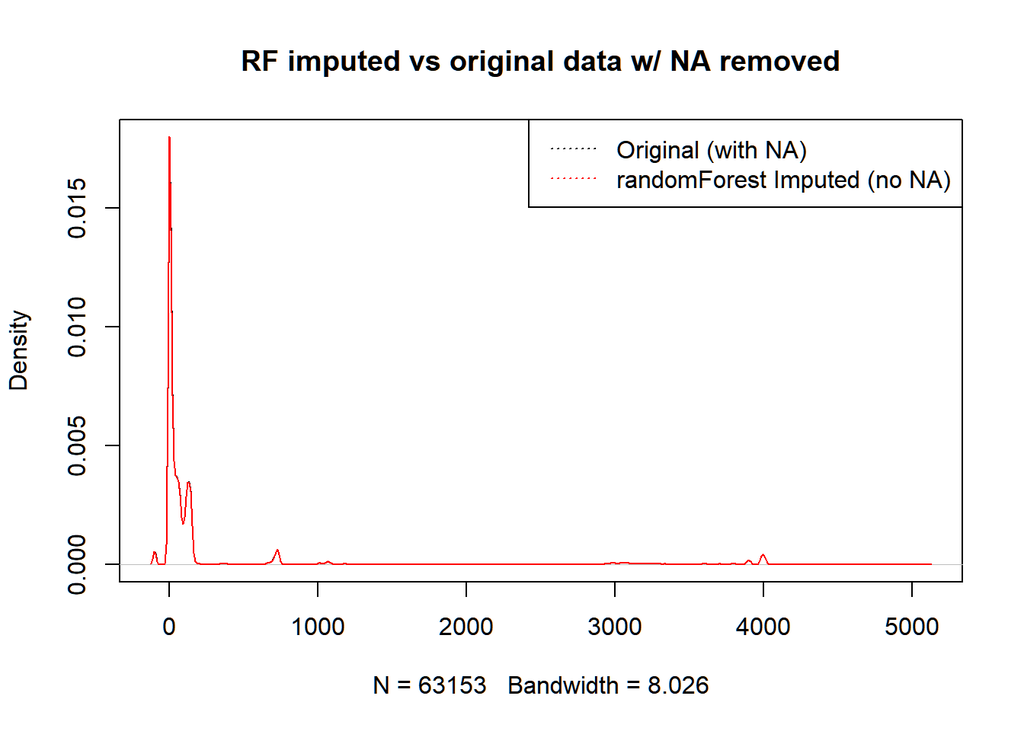

```r
plot(density(unlist(train_data[, -1]), na.rm=TRUE),
     main='RF imputed vs original data w/ NA removed')
lines(density(unlist(rf_imput_train[, -1]), na.rm=TRUE),
      col = 'red')
legend('topright', legend = c("Original (with NA)", "randomForest Imputed (no NA)"),
       col = c("black", "red"), lty = 3)
```

### MICE imputed density plots

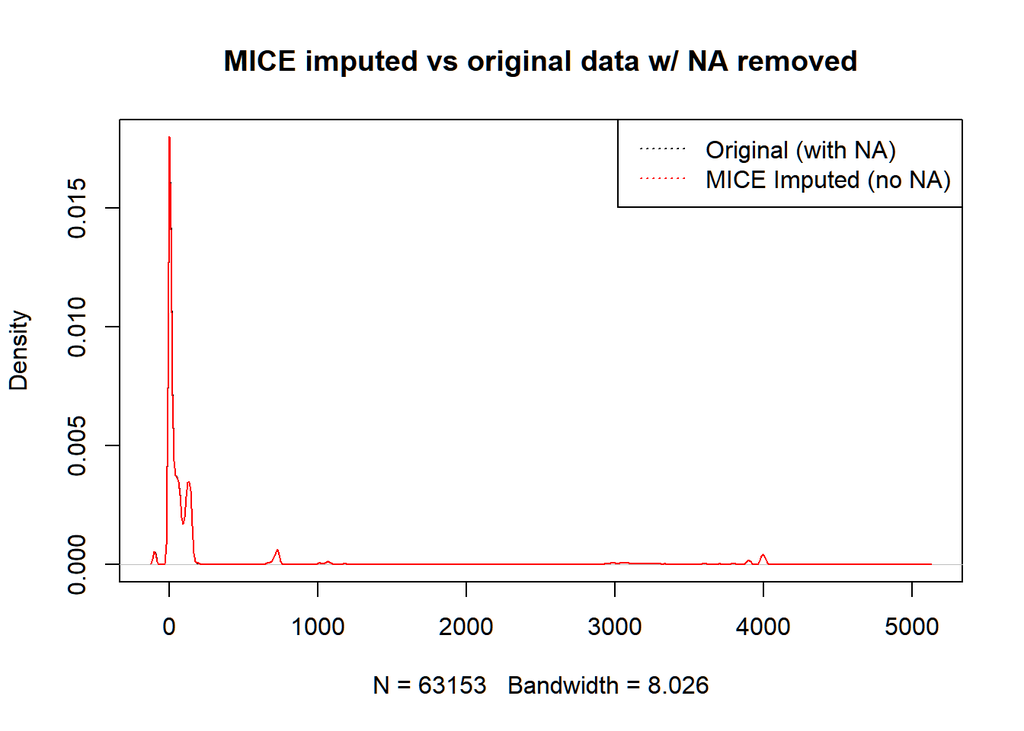

```r
plot(density(unlist(train_data[, -1]), na.rm=TRUE),
     main='MICE imputed vs original data w/ NA removed')
lines(density(unlist(mice_1_train[, -1]), na.rm=TRUE),
      col = 'red')
legend('topright', legend = c("Original (with NA)", "MICE Imputed (no NA)"),
       col = c("black", "red"), lty = 3)
```

**Running a t-test to compare all column values except for the first column for both the original and the imputed dataset. P-value > 0.05, indicating the imputation did not change the overall data structure.**

```r
t.test(train[, -1], mice_1_train[, -1]) #No difference
```

```
##
##  Welch Two Sample t-test
##
## data:  train[, -1] and mice_1_train[, -1]
## t = 0.14608, df = 136603, p-value = 0.8839
## alternative hypothesis: true difference in means is not equal to 0
## 95 percent confidence interval:
##  -7.723202  8.967115
## sample estimates:
## mean of x mean of y
##  254.1059  253.4839
```

```r
t.test(train[, -1], knn_imput_train[, -1]) #Significant difference
```

```
##
##  Welch Two Sample t-test
##
## data:  train[, -1] and knn_imput_train[, -1]
## t = 39.523, df = 128213, p-value < 2.2e-16
## alternative hypothesis: true difference in means is not equal to 0
## 95 percent confidence interval:
##  122.7717 135.5838
## sample estimates:
## mean of x mean of y
##  254.1059  124.9281
```

```r
t.test(train[, -1], rf_imput_train[, -1])#No difference
```

```
##
##  Welch Two Sample t-test
##
## data:  train[, -1] and rf_imput_train[, -1]
## t = 0.16746, df = 136638, p-value = 0.867
## alternative hypothesis: true difference in means is not equal to 0
## 95 percent confidence interval:
##  -7.629477  9.054945
## sample estimates:
## mean of x mean of y
##  254.1059  253.3932
```

**Conclusion: KNN changes the dataset structure significantly, while randomForest and MICE did not. We will exclude KNN imputation and select MICE as our imputation method.**

To separate the predictors from the target variables:

```r
#Separate the PH column from the mice_1_test:
mice_1_test_predictors<- mice_1_test %>% select(-PH)
mice_1_test_target<- mice_1_test$PH
```

## —————————————————————————-

# Data Modeling

## Models:

### Cubist

```r
# Cubist Model
library(Cubist)

# Train Cubist model on MICE-imputed data
set.seed(199)
cubist_model <- train(
  PH ~ .,
  data = mice_1_train,
  method = "cubist",
  trControl = trainControl(method = "cv", number = 5),
  tuneGrid = expand.grid(committees = c(1, 5, 10), neighbors = c(0, 3, 5, 7))
)

# Make predictions on test set
cubist_pred <- predict(cubist_model, newdata = mice_1_test_predictors)

# Evaluate performance using caret functions
cubist_rmse <- caret::RMSE(cubist_pred, mice_1_test_target)
cubist_r2 <- caret::R2(cubist_pred, mice_1_test_target)

# Print results
cat("Cubist Model Performance:\n")
```

```
## Cubist Model Performance:
```

```r
cat("RMSE:", cubist_rmse, "\n")
```

```
## RMSE: 0.103696
```

```r
cat("R-squared:", cubist_r2, "\n")
```

```
## R-squared: 0.6491117
```

```r
# Variable importance
varImp(cubist_model)
```

```
## cubist variable importance
##
##   only 20 most important variables shown (out of 33)
##
##                 Overall
## Mnf.Flow         100.00
## Balling.Lvl       63.46
## Alch.Rel          60.90
## Balling           59.62
## Pressure.Vacuum   55.77
## Air.Pressurer     55.13
## Density           53.85
## Bowl.Setpoint     46.79
## Oxygen.Filler     44.87
## Carb.Rel          40.38
## Filler.Speed      40.38
## Temperature       40.38
## Brand.CodeC       39.74
## Hyd.Pressure3     39.74
## Carb.Pressure1    36.54
## Carb.Flow         33.97
## Carb.Volume       30.77
## Hyd.Pressure2     29.49
## Carb.Pressure     29.49
## Usage.cont        26.92
```

### XGBoosting

```r
# XGBoost Model
library(xgboost)

# Prepare data for XGBoost
xgb_train <- mice_1_train %>% select(-PH)
xgb_test <- mice_1_test %>% select(-PH)

# Convert factors to numeric (XGBoost requires numeric matrix)
xgb_train <- model.matrix(~ . -1, data = xgb_train)
xgb_test <- model.matrix(~ . -1, data = xgb_test)

# Create DMatrix objects
dtrain <- xgb.DMatrix(data = xgb_train, label = mice_1_train$PH)
dtest <- xgb.DMatrix(data = xgb_test, label = mice_1_test$PH)

# Set parameters
params <- list(
  objective = "reg:squarederror",
  eta = 0.01,
  max_depth = 6,
  min_child_weight = 5,
  subsample = 0.8,
  colsample_bytree = 0.8
)

# Train XGBoost model
set.seed(199)
xgb_model <- xgb.cv(
  params = params,
  data = dtrain,
  nrounds = 500,
  nfold = 5,
  early_stopping_rounds = 20,
  print_every_n = 10,
  verbose = 1
)
```

```
## Multiple eval metrics are present. Will use test_rmse for early stopping.
## Will train until test_rmse hasn't improved in 20 rounds.
##
```

```r
# Final model with optimal rounds
final_xgb <- xgboost(
  params = params,
  data = dtrain,
  nrounds = xgb_model$best_iteration,
  verbose = 0
)

# Make predictions
xgb_pred <- predict(final_xgb, dtest)

# Evaluate performance using caret functions
xgb_rmse <- caret::RMSE(xgb_pred, mice_1_test_target)
xgb_r2 <- caret::R2(xgb_pred, mice_1_test_target)

# Print results
cat("\nXGBoost Model Performance:\n")
```

```
##
## XGBoost Model Performance:
```

```r
cat("RMSE:", xgb_rmse, "\n")
```

```
## RMSE: 0.1244964
```

```r
cat("R-squared:", xgb_r2, "\n")
```

```
## R-squared: 0.5951791
```

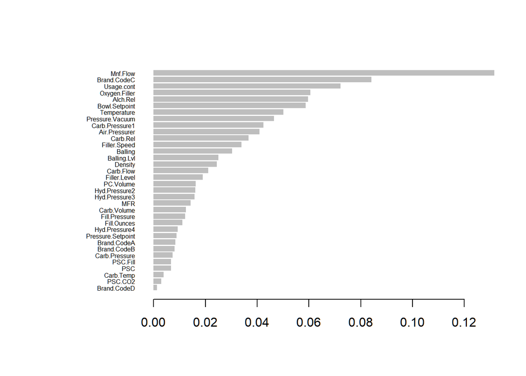

```r
# Variable importance
importance_matrix <- xgb.importance(model = final_xgb)
xgb.plot.importance(importance_matrix)
```